# Exercise 2

Kemei Zhuo

August 18, 2018

## Flights at ABIA

**Flights from Austin**

I separated the dataset into flights that fly from Austin and flights that fly into Austin.

We can see below that arrival delay is not a serious phenomenon because more than half of the flights arrive early. Still, we want to avoid the delay by avoiding the busy hour.

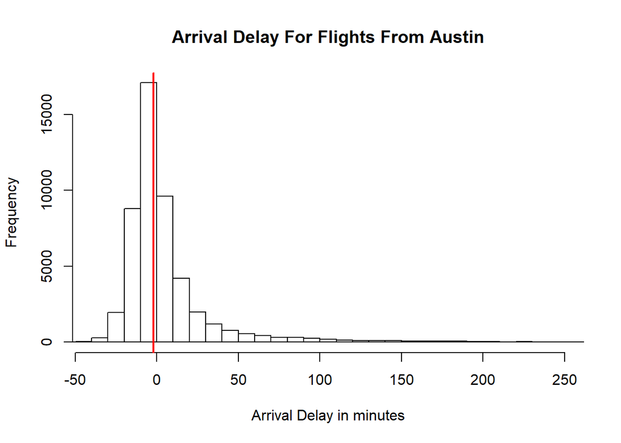

We can see from the histogram of delay in each months that March, June, and December have high delays, but September, October, and November have low delay minutes.

We can aslo see from the histogram of delay in different day of month that the delay increases during the second half of month.

We can also see from histogram of delay in a week that the delay is highest on Friday’s flights.

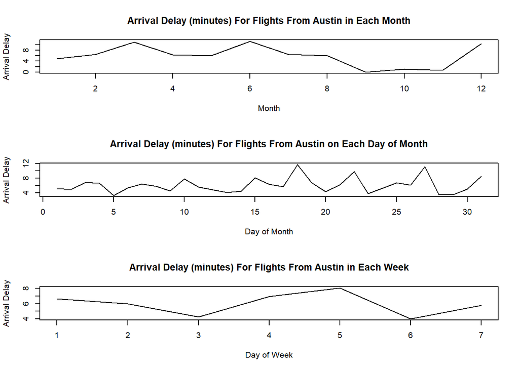

We can also see from histogram of delay in a day that the afternoon flight has highest delay and the flights in morning have lowest delay.

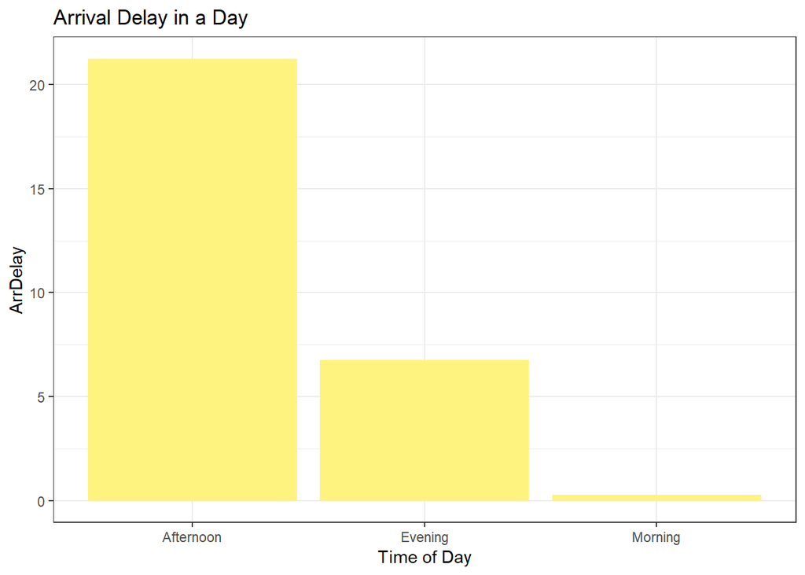

Thus, we should take flights in the first half of month in September, October, and November, avoid the Friday, and choose flight in the morning if we want to fly from Austin.

I am also interested to see whether the delay is related to the number of flights. We can see that

*September, October, November, and December have less number of flights

*The number of flights in each day of month is similiar

*Saturday has less flights.

*The flights in morning > the flights in evening > the flgihts in afternoon

Thus, we can conclude that there’s no relatinoship between arrival delay and numebr of flights.

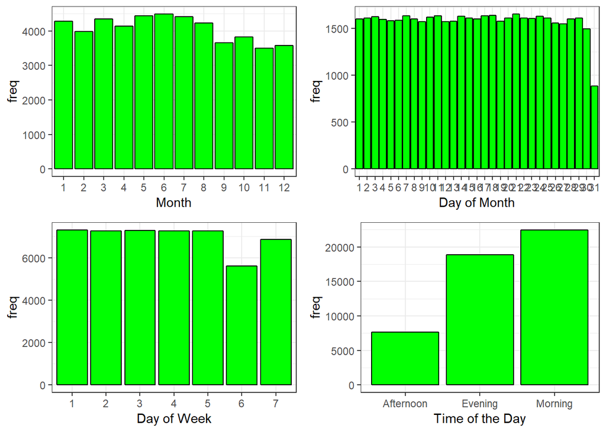

In addition, I wonder if the distance would matter in arrival delay because international flights are almost on time.

*Below we can see that there is no clear relationship.

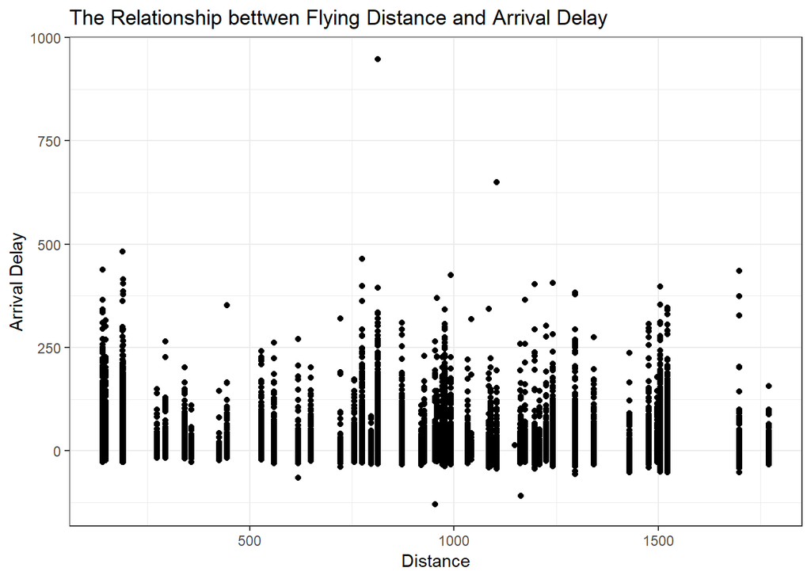

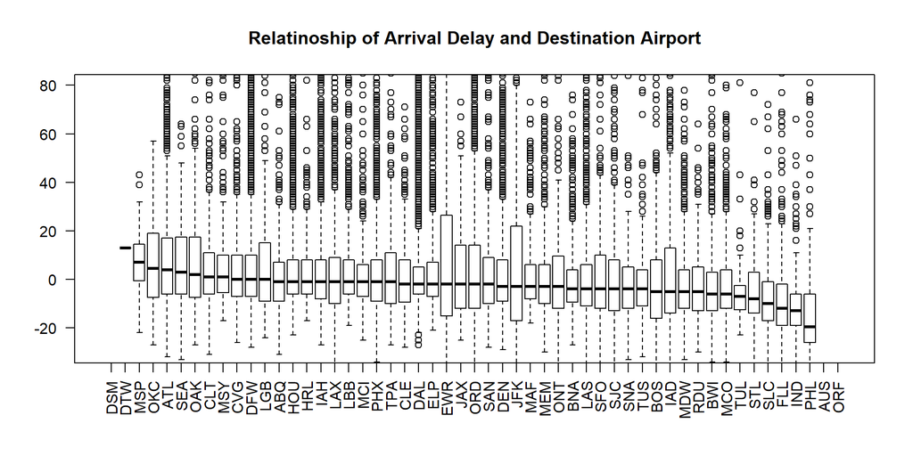

**Flights to Austin**

We can see below that arrival delay histogram is similiar.

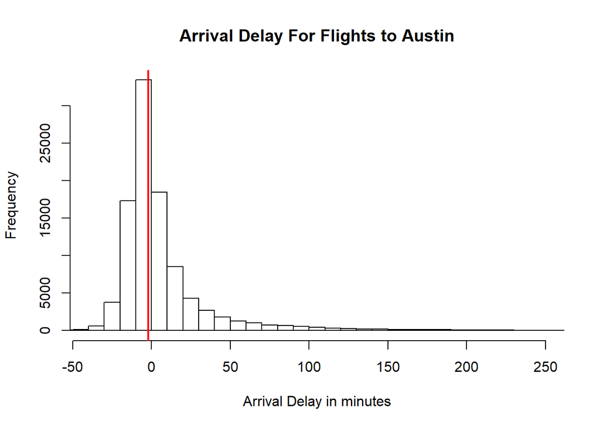

The insights drawn on plots below are very similiar to what we see on flights from Austin.

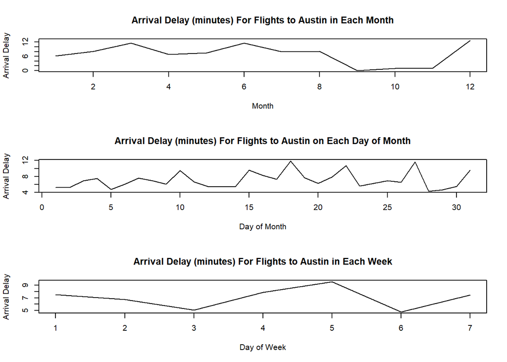

We can also see from histogram of delay in a day that the afternoon flight has highest delay and the flights in morning have lowest delay.

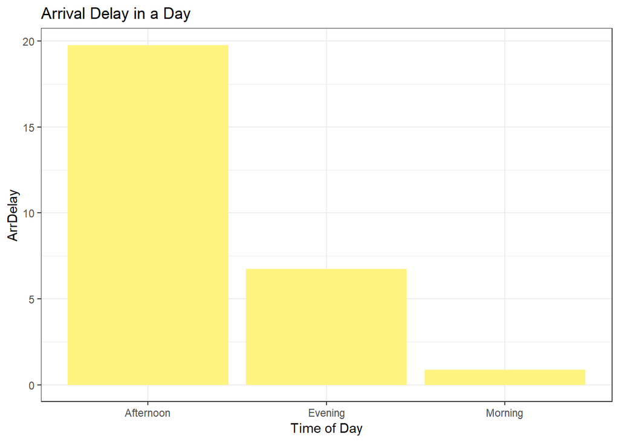

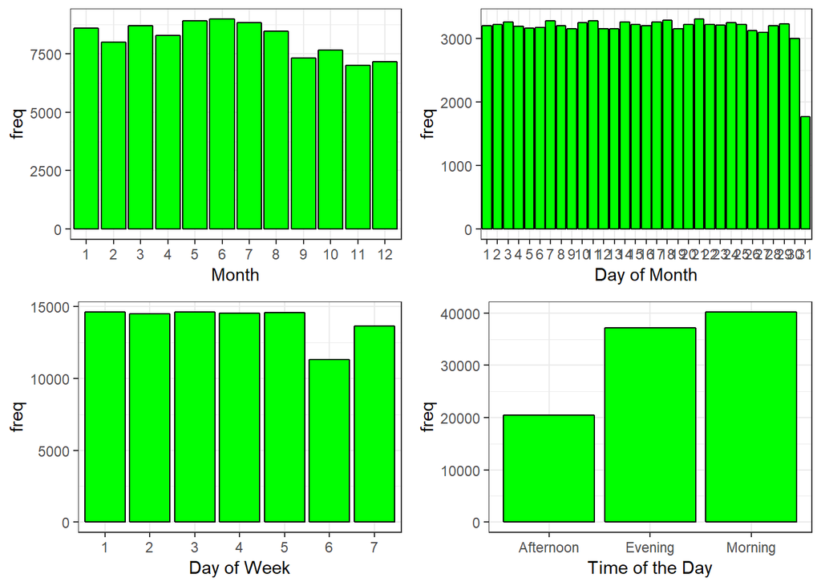

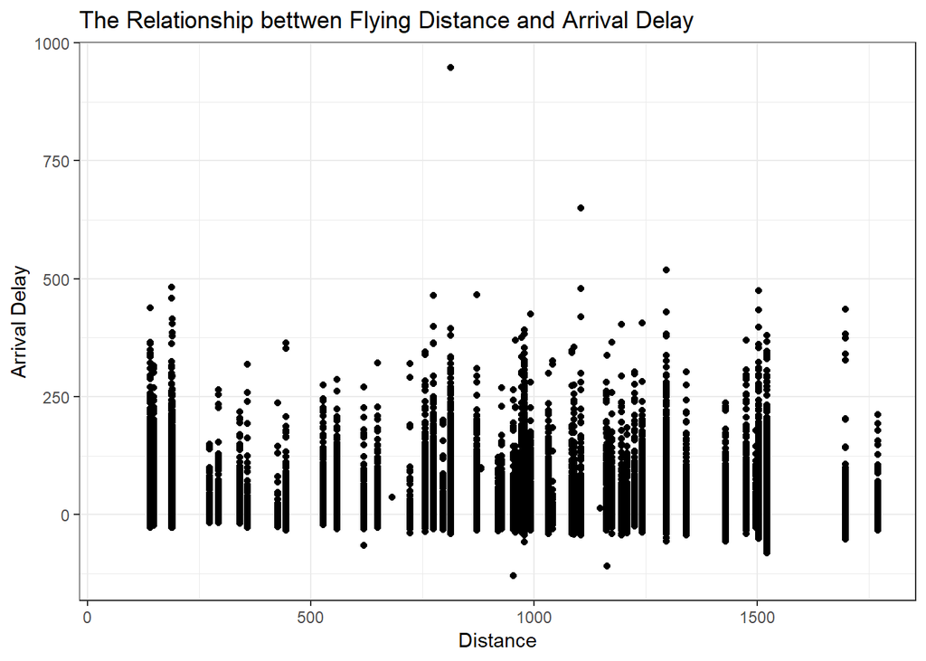

We can see that the airports with highest delay are different.

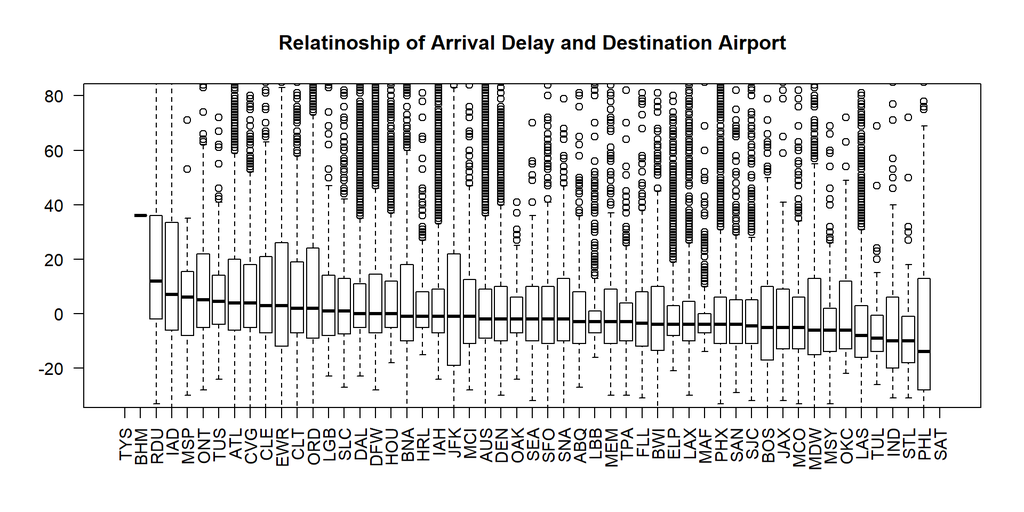

## Author attribution

I used the naivebayes model and random Forest to predict the author identities in the test data. My way of dealing new words in test data is to cut it out in the beginning. I assumed that the same author would have similir word style and thus the new words would not be significant. Thus, I used `control=list(dictionary=sort(Terms(DTM_simon)))` to make sure that the test data has the same column names as the train data, which makes the prediction later much pleasant.

```r
library(tm)
```

```r
library(magrittr)

setwd('C:/Users/zjfhz/Desktop/predictive model/STA380-master')

readerPlain = function(fname){

  readPlain(elem=list(content=readLines(fname)),

            id=fname, language='en') }
# file path

author_dirs1 = Sys.glob('data/ReutersC50/C50train/*')

author_dirs2 = Sys.glob('data/ReutersC50/C50test/*')

file_list = NULL

file_list1 = NULL

labels = NULL

labels1 = NULL

labels2 = NULL

for(author in author_dirs1) {

  files_to_add = Sys.glob(paste0(author, '/*.txt'))

  file_list = append(file_list, files_to_add)

  author_name = substring(author, first=29)

  labels1 = append(labels1, rep(author_name, length(files_to_add)))
}

for(author in author_dirs2) {

  files_to_add = Sys.glob(paste0(author, '/*.txt'))

  file_list1 = append(file_list1, files_to_add)

  author_name = substring(author, first=28)

  labels2 = append(labels2, rep(author_name, length(files_to_add)))
}

file_list2 = append(file_list,file_list1)

labels <- unique(append(labels1, labels2))

docs1 = lapply(file_list, readerPlain)
docs2 = lapply(file_list1, readerPlain)

name1 = file_list %>%

{ strsplit(., '/', fixed=TRUE) } %>%

{ lapply(., tail, n=2) } %>%

{ lapply(., paste0, collapse = '') } %>%

  unlist

name2 = file_list1 %>%

{ strsplit(., '/', fixed=TRUE) } %>%

{ lapply(., tail, n=2) } %>%

{ lapply(., paste0, collapse = '') } %>%

  unlist
# Rename the articles

names(docs1) = name1
names(docs2) = name2


documents_raw = Corpus(VectorSource(docs1))

my_documents = documents_raw

my_documents = tm_map(my_documents, content_transformer(tolower)) # make everything lowercase

my_documents = tm_map(my_documents, content_transformer(removeNumbers)) # remove numbers

my_documents = tm_map(my_documents, content_transformer(removePunctuation)) # remove punctuation

my_documents = tm_map(my_documents, content_transformer(stripWhitespace)) ## remove excess white-space

my_documents = tm_map(my_documents, content_transformer(removeWords), stopwords("en"))

DTM_simon = DocumentTermMatrix(my_documents)

DTM_simon = removeSparseTerms(DTM_simon, 0.95)

X_train = as.matrix(DTM_simon)

documents_raw = Corpus(VectorSource(docs2))

my_documents = documents_raw

my_documents = tm_map(my_documents, content_transformer(tolower)) # make everything lowercase

my_documents = tm_map(my_documents, content_transformer(removeNumbers)) # remove numbers

my_documents = tm_map(my_documents, content_transformer(removePunctuation)) # remove punctuation

my_documents = tm_map(my_documents, content_transformer(stripWhitespace)) ## remove excess white-space

my_documents = tm_map(my_documents, content_transformer(removeWords), stopwords("en"))

DTM_simon = DocumentTermMatrix(my_documents, control=list(dictionary=sort(Terms(DTM_simon))))

X_test = as.matrix(DTM_simon)

# reorder the column names
X_train = X_train[ , order(colnames(X_train))]
X_test = X_test[ , order(colnames(X_test))]
```

```r
library(e1071)
data_trn = cbind(data.frame(X_train), labels1)
model1 = naiveBayes(labels1~., data=data_trn, laplace=1)
X_test = data.frame(X_test)
y_test = labels2
pred_nb = predict(model1, X_test)
t=table(pred_nb, y_test)
sum(diag(t))/length(y_test)
```

```
## [1] 0.2828
```

```r
library(randomForest)
model2 = randomForest(labels1~., data=data_trn)
pred_rf = predict(model2, X_test)
t=table(pred_rf, labels2)
sum(diag(t))/length(y_test)
```

```
## [1] 0.6072
```

```r
# look at prediction on each author
sort(diag(t))
```

```
##       idLawder       ttHillis       uelPerry     aFernandes       cAuchard
##              8             11             12             13             14
##     eMacartney        dNissen  renSchuettler        tinWolk    xanderSmith
##             15             17             17             17             18
##  therScoffield   jaminKangLim      liamKazer        eDickie      ahDavison
##             19             20             21             22             24
##        rreTran     nardHickey          Ortiz     inMorrison    resePoletti
##             24             25             25             27             28
##     stinRidley      nMastrini    inDrawbaugh       dDorfman     haelConnor
##             28             29             30             31             31
##         iaZajc     erHumphrey        Lopatka        Farrand         kLouth
##             31             33             33             34             34
##          EeLyn       onCowell      athanBirt        nCrosby    interbottom
##             35             35             36             36             37
##   riciaCommins         thWeir   celMichelson      kBendeich    neO'Donnell
##             37             38             40             41             41
##    hamEarnshaw        inSidel      erFillion       lPenhaul roshKarimkhany
##             42             42             43             44             45
##      thewBunce     onPressman    ikoFujisaki   nleyBrowning      Gilchrist
##             45             46             47             47             50
```

# Practice with association rule mining

After I read the data, I created the apriori algorithem that has support higher than 0.005 and confidence larger than .2.

```r
#'apriori' algorithm
rules = apriori(groceries,
                     parameter=list(support=.005, confidence=.2, maxlen=5))
```

[output not shown]

```
## To reduce overplotting, jitter is added! Use jitter = 0 to prevent jitter.
```

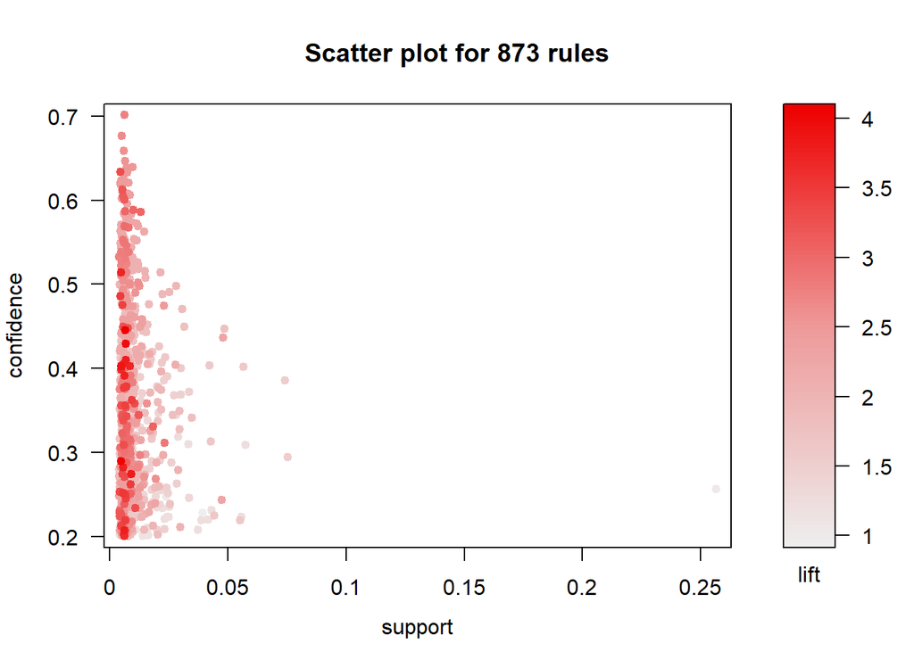

```r
plot(rules)
```

Here we had 873 rules and I’d like to trim down the rules to the ones that are more important.

We can see that

- berries, whipped/sour cream, and better is clustered together. These three are bought together
- citrus fruit, pip fruit, and tropical fruit is close.
- yogurt stands alone
- herbs stands alone
- whole milk, other vegetables, toot vegetables are in the center, which means that most people would buy them when they do grocery shopping.

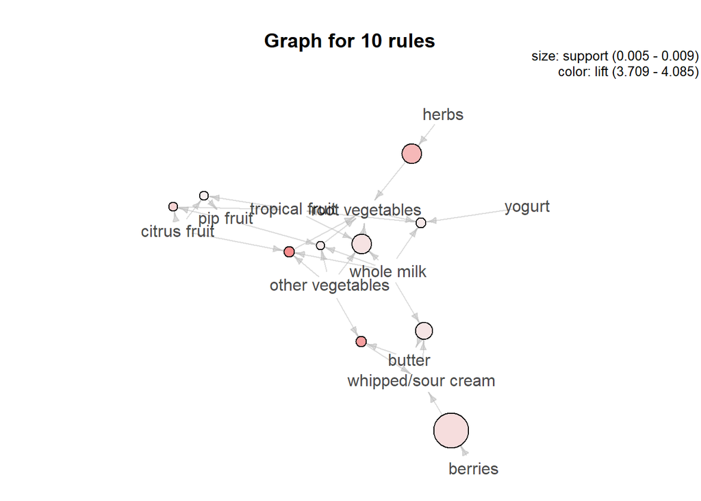

```r
subrules2 = head(sort(rules, by="lift"), 10)
plot(subrules2, method='graph')
```

```r
inspect(subrules2)
```

```
##      lhs                     rhs                      support confidence     lift count
## [1]  {citrus fruit,
##       other vegetables,
##       whole milk}         => {root vegetables}    0.005795628  0.4453125 4.085493    57
## [2]  {butter,
##       other vegetables}   => {whipped/sour cream} 0.005795628  0.2893401 4.036397    57
## [3]  {herbs}              => {root vegetables}    0.007015760  0.4312500 3.956477    69
## [4]  {citrus fruit,
##       pip fruit}          => {tropical fruit}     0.005592272  0.4044118 3.854060    55
## [5]  {berries}            => {whipped/sour cream} 0.009049314  0.2721713 3.796886    89
## [6]  {other vegetables,
##       tropical fruit,
##       whole milk}         => {root vegetables}    0.007015760  0.4107143 3.768074    69
## [7]  {whipped/sour cream,
##       whole milk}         => {butter}             0.006710727  0.2082019 3.757185    66
## [8]  {root vegetables,
##       whole milk,
##       yogurt}             => {tropical fruit}     0.005693950  0.3916084 3.732043    56
## [9]  {other vegetables,
##       pip fruit,
##       whole milk}         => {root vegetables}    0.005490595  0.4060150 3.724961    54
## [10] {citrus fruit,
##       tropical fruit}     => {pip fruit}          0.005592272  0.2806122 3.709437    55
```